# Assignment 13

Robert Wilbrand

15.2.2021

```r
library(raster)
library(tidyverse)
library(sf)
library(MuMIn)
theme_set(theme_minimal())
knitr::opts_knit$set(root.dir = "C:/MSc GCG/QM/Data/data")
knitr::opts_chunk$set(message = FALSE, warning = FALSE)
options(scipen = 8)
```

# A simple species distribution model.

The goal of this exercise is to build a simple statistical species distribution model for *Abies alba*. We will use a Europe-wide tree species occurrence data set (Mauri et al., 2017) as reference and the Bioclim dataset as predictors.

Mauri, A., Strona, G., & San-Miguel-Ayanz, J. (2017). EU-Forest, a high-resolution tree occurrence dataset for Europe. Sci Data, 4, 160123

## 1) Calculate the count of *Abies alba* observations within each Bioclim grid cell (2 Points):

We start by importing the dataset (“abiesalba.csv”) and visualizing the observed occurrence of *Abies alba*. To make this occurrence dataset spatially comparable to the predicted map that we will build later, I want you to create a raster of the occurrence counts at the spatial resolution of the bioclim dataset (bioclim_europe.tif). Check out the raster::rasterize() function to achieve this.

You can download the bioclim_europe.tif from: https://1drv.ms/u/s!AqNb6reoHXeZoq9JzbzkiwU_Gqu06w?e=wejkdx. The bioclim_europe raster has an equal-area projection (EPSG:3035, see: https://spatialreference.org/ref/epsg/etrs89-etrs-laea/).

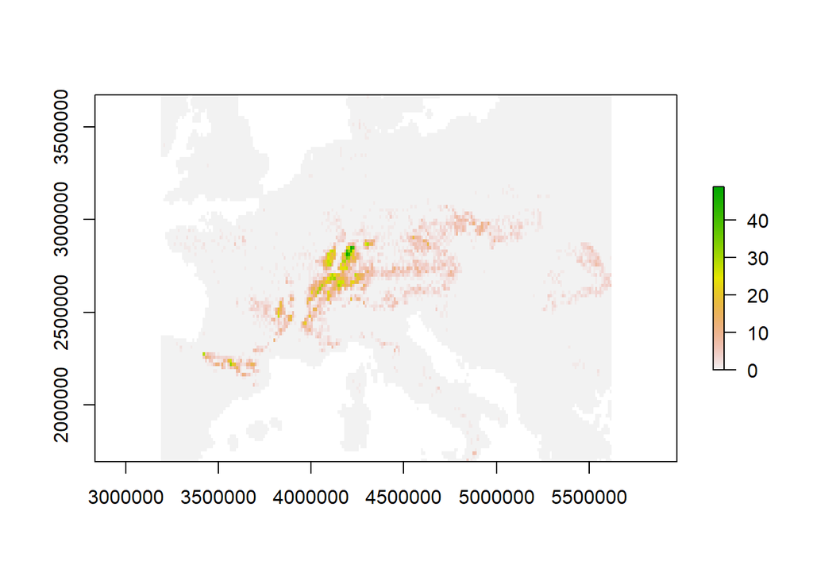

```r
# load occurrence data
abies <- read_csv("abiesalba.csv")

# convert to sf and transform CRS based on EPSG code
abies_sf <- st_as_sf(abies,
                     coords = c("long", "lat"),
                     crs = 4326) %>%
  st_transform(3035)

# extract extent object of observed abies occurrences
ext_abies <- extent(abies_sf)

# load bioclim data
bioclim_europe <- stack("bioclim_europe.tif")
names(bioclim_europe) <- c(paste0("bio0", 1:9),
                           paste0("bio", 10:19))

# rasterize occurrences with a template based on bioclim raster
ras <- raster(bioclim_europe)
abies_count <- rasterize(abies_sf, ras, fun = "count", background = 0)

# use one of the bioclim layers to mask NAs
abies_count <- mask(abies_count, bioclim_europe[[1]])
plot(abies_count, ext = ext_abies)
```

## 2) Prepare a dataset combining response and predictor variables (3 Points):

Before we can train our statistical model, we need to create a random sample from our response and predictor variables. The result should be a data.frame. Note, stack the bioclim and count raster before sampling.

When sampling, you have two options: 1) a random sample of 20% of the observed grid-cells, OR 2) create a stratified sample containing 20% of the observations in each count class.

Option 2 gets extra points. Hint: You can combine dplyr::group_by() and dplyr::sample_frac()!

```r
# stack bioclim and occurrence data, crop to abies extent
bc_abies <- stack(bioclim_europe, abies_count)
bc_cropped <- crop(bc_abies, ext_abies)

# convert to tibble
# because high numbers of counts have few occurrences, I aggregate classes: 9-12 counts, 13-20 counts, 21-30 counts, 30+ counts
bc_abies_tbb <- as.data.frame(bc_cropped, xy = T, na.rm = T) %>%
  as_tibble %>%
  rename(abies = layer) %>%
  relocate(abies) %>%
  mutate(count_class = cut(abies,
                           breaks = c(0:8, 12, 20, 30, Inf),
                           include.lowest = T))

# stratified sampling with 20% per class
set.seed(4832)
bc_abies_sample <- bc_abies_tbb %>%
  group_by(count_class) %>%
  slice_sample(prop = 0.2) %>%
  ungroup
```

## 3) Build a model predicting the count of *Abies alba* (3 Points)

Use a GLM to predict the occurrence of *Abies alba* from bioclim data. You can hand-pick variables or use a variable selection technique. Your choice.

```r
# Preparation step, without this option, dredge() from the MuMIn package likely fails
options(na.action = "na.fail")

# Function to automatically generate an exhaustive formula for modeling
# Dependent variable is assumed to be in column 1 by default
# Columns not to be used can be specified by index with exclude
exh_formula <- function(df, i = 1, exclude = NULL){
  j <- c(i, exclude)
  paste(colnames(df)[i], " ~ ",
        paste(colnames(df)[-j],
              collapse = " + ")) %>%
  as.formula
}

# Interaction terms are not considered due to concerns about excessive computation time and because some terms already implicitly consider interactions (e.g. BIO8: Mean temperature of wettest quarter)
# BIO3 and BIO7 are excluded because they are linearly dependent on other variables
full_form <- select(bc_abies_sample, abies, starts_with("bio")) %>%
  exh_formula(exclude = c(4,8))

# With positively bounded count data, I choose a Poisson distribution model
full_mod <- glm(full_form, bc_abies_sample,
                family = poisson(link = "log"))
```

Computation of the following chunk was done in an interactive session and is not repeated here (eval=FALSE) due to long computation time (>2h).

```r
starttime <- Sys.time()
dmod <- dredge(full_mod)
endtime <- Sys.time()
endtime - starttime
saveRDS(dmod, "Abies_models.rds")
```

```r
dmod <- read_rds("Abies_models.rds")

picked.model <- getCall(dmod, 1) %>% eval
```

The best-performing model when using dredge() uses all of the selected predictors except for BIO19.

## 4) Create a map of the predicted *Abies alba* counts (2 Point)

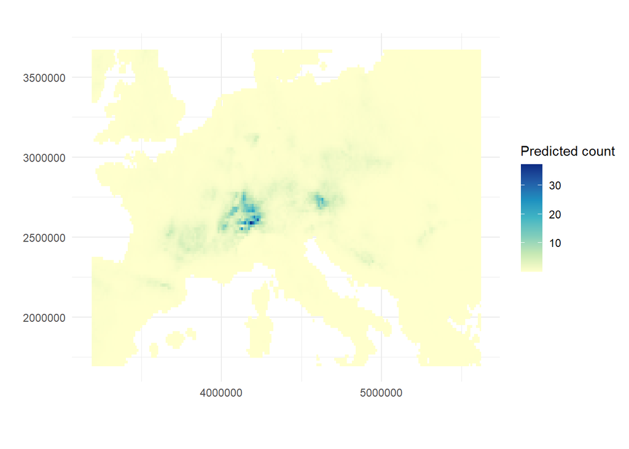

```r
# create prediction
pred <- raster::predict(bc_cropped, picked.model)

# convert to tibble
# predictions need to be back-transformed with exp()
pred_df <- as.data.frame(pred, xy = T) %>%
  as_tibble %>%
  mutate(abies_pred = exp(layer))

# join prediction to data tibble to calculate difference between prediction and observation
joined_df <- left_join(bc_abies_tbb, pred_df) %>%
  mutate(difference = abies - abies_pred)

# plot predicted abies counts
ggplot(joined_df, aes(x, y, fill = abies_pred)) +
  geom_raster() +
  scale_fill_distiller(palette = "YlGnBu", direction = 1) +
  labs(x = "", y = "", fill = "Predicted count") +
  coord_fixed()
```

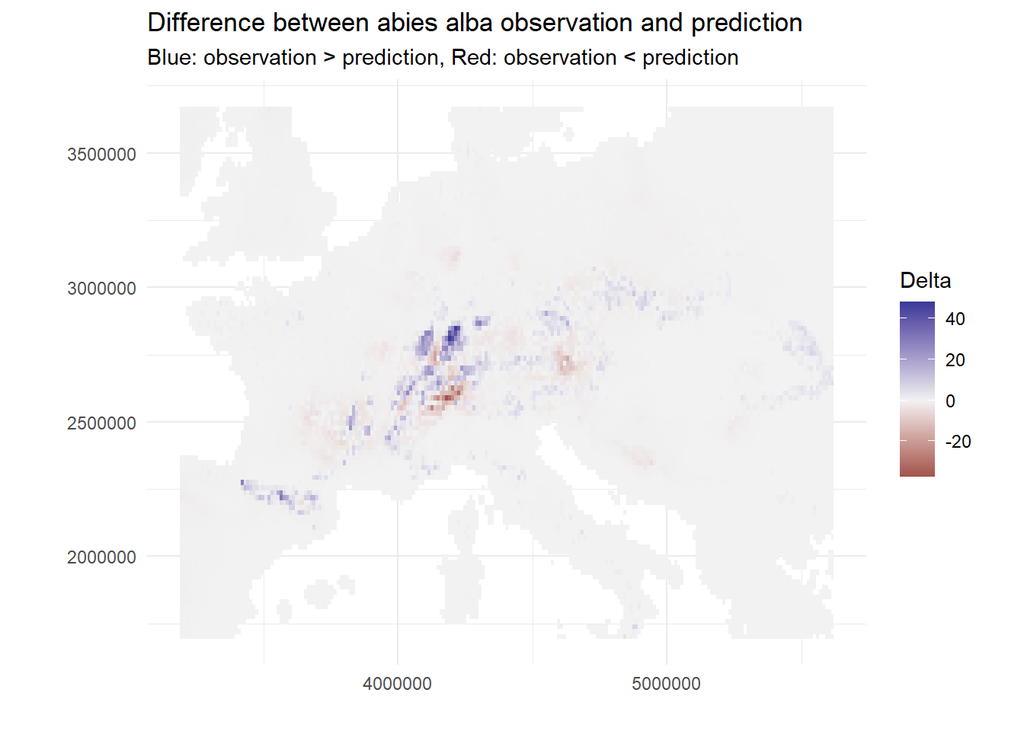

```r
# plot difference
ggplot(joined_df, aes(x, y, fill = difference)) +
  geom_raster() +
  scale_fill_gradient2(mid = "grey95") +
  labs(x = "", y = "", fill = "Delta",
       title = "Difference between abies alba observation and prediction",
       subtitle = "Blue: observation > prediction, Red: observation < prediction") +
  coord_fixed()
```

Discrepancies between observed and predicted counts are not surprising, because tree occurrence is likely to be influenced by factors other than climate data, e.g. land management and topography